# Tema 3 - Distribuciones Notables

## Distribuciones Notables.

## Introducción

- En este tema estudiaremos diversos tipos de experimentos que son muy frecuentes y algunas de las variables aleatorias asociadas a ellos.
- Estas variables reciben distintos nombres que aplicaremos sin distinción al tipo de población del experimento a la variable o a su función de probabilidad, densidad o distribución.
- Empezaremos con las variables aleatorias discretas que se presentan con frecuencia ya que están relacionadas con situaciones muy comunes como el número de caras en varios lanzamiento de una moneda, el número de veces que una maquina funciona hasta que se estropea, el numero de clientes en una cola,…

## Distribuciones Discretas.

## Distribución Bernoulli

Distribución Bernouilli

- Consideremos un experimento con dos resultados posibles éxito (E) y fracaso (F). El espacio de sucesos será \(\Omega=\{E,F\}\).
- Supongamos que la probabilidad de éxito es \(P(E)=p\), y naturalmente \(P(F)=1-p=q\) con \(0<p<1\).
- Consideremos la aplicación

\[ X:\Omega=\{E,F\}\to \mathbb{R}\]

definida por

\[X(E)=1\mbox{, }X(F)=0\]

## Distribución Bernoulli

- Su función de probabilidad es

\[ P_{X}(x)= \left\{ \begin{array}{ll} q & \mbox{si } x=0\\ p & \mbox{si } x=1\\ 0 & \mbox{en cualquier otro caso} \end{array} \right. \]

## Distribución Bernoulli

- Bajo estas condiciones diremos que \(X\) **es una v.a. Bernoulli** o que sigue una ley de **distribución de probabilidad Bernoulli** de parámetro \(p\).
- Lo denotaremos por \[X\equiv Ber(p)\mbox{ o también } X\equiv B(1,p).\]
- A este tipo de experimentos (éxito/fracaso)se les denomina experimentos Bernoulli.
- Fue [Jacob Bernoulli](https://es.wikipedia.org/wiki/Jakob_Bernoulli) científico suizo y una más de la de la [familia de científicos suizos Bernoulli](https://es.wikipedia.org/wiki/Familia_Bernoulli)

## Resumen v.a con distribución Bernoulli, \(Ber(p)\)

| Bernoulli | \(Ber(p)\) |
| --- | --- |
| \(D_X=\) | \(\{0,1\}\) |
| \(P_X(x)=P(X=x)=\) | \(\left\{\begin{array}{ll} q & \mbox{si } x=0\\ p & \mbox{si } x=1\\0 & \mbox{en otro caso}\end{array}\right.\) |
| \(F_X(x)=P(X\leq X)=\) | \(\left\{\begin{array}{ll} 0 & \mbox{ si } x<0\\q & \mbox{ si } 0\leq x<1\\1 & \mbox{ si } 1\leq x \end{array}\right.\) |
| \(E(X)=p\) | \(Var(X)=p\cdot q\) |

## Veamos los cálculos básicos \(Ber(p=0.25)\)

```r
dbinom(0,size=1,prob=0.25)
```

```
## [1] 0.75
```

```r
dbinom(1,size=1,prob=0.25)
```

```
## [1] 0.25
```

```r
rbinom(n=20,size = 1,prob=0.25)
```

```
##  [1] 0 0 0 0 0 0 0 0 1 0 0 0 0 0 0 1 0 0 0 1
```

## Gráficos de la distribución \(Ber(p=0.25)\)

El siguiente código dibuja las función de probabilidad y la de distribución de una \(Ber(p=0.25)\)

```r
plot(x=c(0,1),y=dbinom(c(0,1),size=1,prob=0.25),
    ylim=c(0,1),xlim=c(-1,2),xlab="x",
    main="Función de probabilidad\n Ber(p=0.25)")
lines(x=c(0,0,1,1),y=c(0,0.75,0,0.25), type = "h", lty = 2,col="blue")
curve(pbinom(x,size=1,prob=0.25),
    xlim=c(-1,2),col="blue",
    main="Función de distribución\n Ber(p=0.25)")
```

## Gráficos de la distribución \(Ber(p=0.25)\)

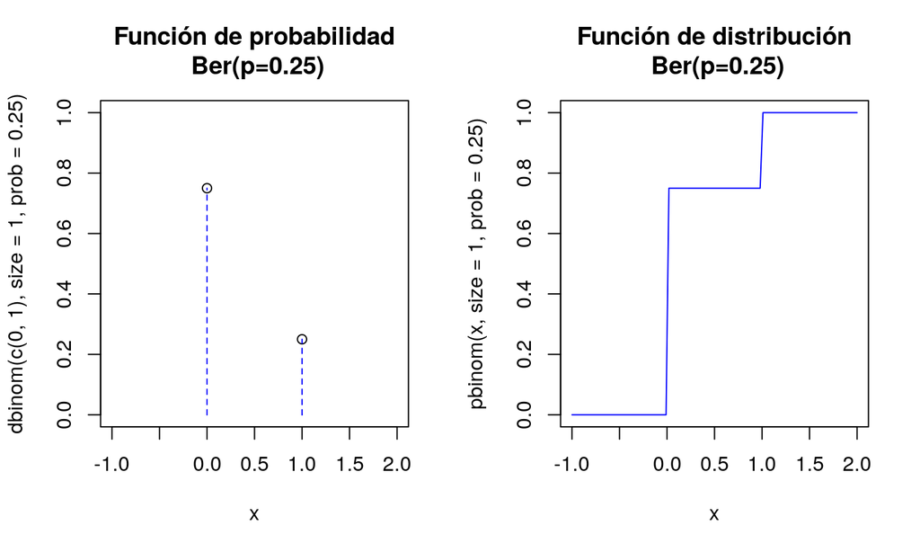

## Distribución binomial

## Distribución binomial

Distribución binomial

Si repetimos \(n\) veces de forma independiente un experimento Bernoulli de parámetro \(p\).

El espacio muestral \(\Omega\) estará formado por cadenas de \(E\)’s y \(F\)’s de longitud \(n\) Consideremos la v.a.

\[X(\overbrace{EFFF\ldots EEF}^{n})=\mbox{número de éxitos en la cadena}.\]

## Función de probabibildad de la distribución binomial

Entonces su **función de probabilidad** es

\[P_{X}(x)=\left\{ \begin{array}{ll} \left(\begin{array}{ll} n\\ x\end{array}\right) p^x (1-p)^{n-x} &\mbox{ si } x=0,1,\ldots,n\\ 0 & \mbox{ en otro caso} \end{array}\right..\]

## Números binomiales con R

Los números binomiales nos calculan cuanto equipos de baloncesto (\(k=5\) jugadores) se pueden hacer con 6 jugadores (\(n=6\)).

Es decir cuántas manearas distintas hay para elegir (*choose*) 5 jugadores en un conjunto de 6 jugadores. Todo el mundo diria ¡¡¡6!!!. Efectivamente con R es

```r
choose(6,5)
```

```
## [1] 6
```

Si son 10 jugadorespara elegir 5 el número de queipos distintos es bastante más grande

```r
choose(10,5)
```

```
## [1] 252
```

## Distribución Binomial

En las anteriores circunstancias diremos que la v.a. sigue una **ley de probabilidad binomial** … con parámetros \(n\) y \(p\) y lo denotaremos así

\[X\equiv B(n,p).\]

Obviamente se tiene que una bernoulli es una binomial con \(n=1\)

\[B(1,p)=Ber(p).\]

Ejercicio:

Calculad las funciones de distribución de una binomial \(B(n=1,p=0.3)\) y comprobar que coinciden con las distribuciones de una \(Ber(p=0.3)\).

## Observaciones sobre la distribución binomial

- La probabilidad de fracaso la denotaremos con \(q=1-p\), **sin ningún aviso adicional**.
- Su **función de distribución no tienen una formula general**, hay que calcularla con una función de R o python… En el siglo pasado se tabulaban en los libros de papel :-).
- En el material adicional os pondremos unas tablas de esta distribución para distintos valores de \(n\) y \(p\) para que disfrutéis de tan ancestral método de cálculo.
- Cualquier paquete estadístico, hoja de cálculo dispone de funciones para el cálculo de estas probabilidades, así que el **uso de las tablas** queda **totalmente anticuado**.

## Resumen v.a con distribución binomial \(B(n,p)\)

| **Binomial** | \(B(n,p)\) |
| --- | --- |
| \(D_X=\) | \(\{0,1,\ldots n\}\) |
| \(P_X(x)=P(X=x)=\) | \(\left\{\begin{array}{ll}{n\choose x}\cdot p^x\cdot (1-p)^{n-x} & \mbox{ si } x=0,1,\ldots,n\\0 & \mbox{ en otro caso.}\end{array}\right.\) |
| \(F_X(x)=P(X\leq X)=\) | no tiene fórmula (utilizad funciones de R o python) |
| \(E(X)=\) | \(n\cdot p\) |
| \(Var(X)=\) | \(n\cdot p \cdot (1-p)\) |

## Cálculos con R

Veamos los cálculos básicos con funciones de R para una v.a \(X\) con distribución binomial \(B(n=10,p=0.25)\).

**Función de distribución** \(P(X\leq 0)\) y \(P(X\leq 4)\):

```r
pbinom(0,size=10,prob=0.25)
```

```
## [1] 0.05631351
```

```r
pbinom(4,size=10,prob=0.25)
```

```
## [1] 0.9218731
```

## Cálculos binomial con R

**Función de probabilidad** \(P(X=0)\) y \(P(X=4)\):

```r
dbinom(0,size=10,prob=0.25)
```

```
## [1] 0.05631351
```

```r
dbinom(4,size=10,prob=0.25)
```

```
## [1] 0.145998
```

## Cálculos binomial con R

**Generación de muestras aleatorias binomial**

Generaremos una muestra aleatoria de 100 valores de una población \(B(20,0.5)\)

```r
rbinom(100,size = 20,prob=0.5)
```

```
##   [1]  9 11 11  9 10 10 10  9  9 11 12 10 10 10 12 15  6 12 12  9  5 10 11
##  [24] 13 11 10 12  8  8 11 11 10 11  9 11 10 11  9 10 12  8 10  7  9  7  9
##  [47] 13 11 12 10  9  8 10 12 10  9 13 11 10 14 12  9 13  9  8 12 12 11  8
##  [70] 10 11 10 10  8 13 13 13  9  8 14 12 11  9 15  6 10 11 10  9 11  9 10
##  [93] 10  6 11 14 11 10 10  9
```

Ejemplo: EL ejemplo anterior correspondería a repetir 100 veces el experimento lanzar una moneda 20 veces y contar el número de caras.

## Cálculos binomial con python

Veamos los cálculos básicos con funciones de python para una v.a \(X\) con distribución binomial \(B(n=10,p=0.25)\).

Primero importamos la función `binom` de la librería `scipy.stat`

```python
from scipy.stats import binom
```

## Cálculos binomial con python

**Función de distribución** \(P(X\leq 0)\) y \(P(X\leq 4)\)

```python
binom.cdf(0,n=10,p=0.25)
```

```
## 0.056313514709472656
```

```python
binom.cdf(4,n=10,p=0.25)
```

```
## 0.9218730926513672
```

## Cálculos binomial con python

**Función de probabilidad** \(P(X=0)\) y \(P(X=4)\):

```python
binom.pmf(0,n=10,p=0.25)
```

```
## 0.056313514709472684
```

```python
binom.pmf(4,n=10,p=0.25)
```

```
## 0.14599800109863295
```

## Cálculos distribución binomial con python

```python
binom.rvs(n=100,p=0.25,size = 20)
```

```
## array([20, 36, 19, 24, 31, 24, 24, 26, 26, 22, 25, 21, 29, 26, 25, 34, 18,
##        28, 25, 18])
```

Notemos que la secuencia aleatoria generada no es la misma que con R. De hecho volvemos a ejecutarla obtendremos una muestra aleatoria distinta.

## Cálculos binomial con python

```python
binom.pmf(0,5,0.4)
```

```
## 0.07776
```

```python
binom.pmf(1,10,0.25)
```

```
## 0.18771171569824247
```

```python
binom.rvs(n=20,p=0.25,size=10)
```

```
## array([ 9,  6,  7,  2,  5,  2,  5, 10,  9,  6])
```

## Gráficos de la distribución binomial con R

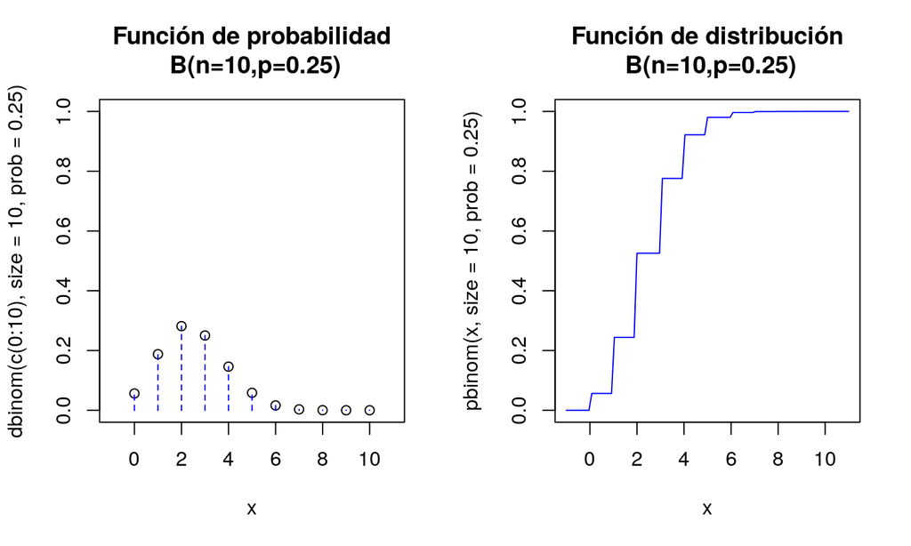

## Gráficos de la distribución binomial con python

Ejercicio Buscad en los manuales de python cómo se dibuja la función de probabilidad y de distribución de una binomial.

Necesitamos más librerías

```python
import numpy as np
import matplotlib.pyplot as plt
```

```python
n, p = 5, 0.4
x = np.arange(binom.ppf(0.01, n, p),binom.ppf(0.99, n, p))
plt.plot(x, binom.pmf(x, n, p), 'bo', ms=8, label='binom pmf')
plt.vlines(x, 0, binom.pmf(x, n, p), colors='b', lw=5, alpha=0.5)
```

## Gráficos de la distribución binomial con python (GGGGRANDES)

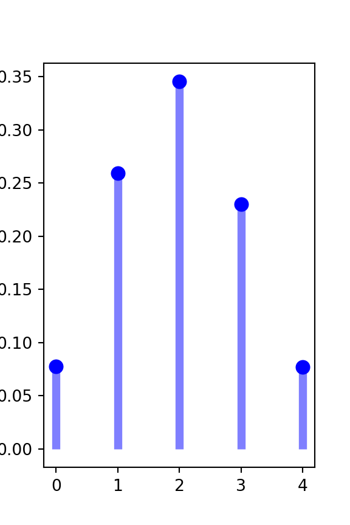

## Distribución geométrica

## Distribución geométrica

Distribución geométrica

- Repitamos un experimento Bernoulli, de parámetro p, de forma independiente hasta obtener el primer éxito.
- Sea \(X\) la v.a. que cuenta el número de fracasos antes del primer éxito. Por ejemplo que hayamos tenido \(x\) fracasos será una cadena de \(x\) fracasos culminada con un éxito. Más concretamente

\[P(\overbrace{FFF\ldots F}^{x}E)=P(F)^{x}\cdot P(E)=(1-p)^{x}\cdot p=q^{x}\cdot p.\]

## Distribución Geométrica

Su función de probabilidad es

\[ P_X(x)=P(X=x)=\left\{\begin{array}{ll} (1-p)^{x}\cdot p & \mbox{ si } x=0,1,2,\ldots\\ 0 &\mbox{ en otro caso} \end{array}\right.. \]

- De una v.a. como esta diremos que sigue una distribución geométrica de parámetro \(p\)..
- La denotaremos por \(Ge(p)\).
- Su dominio es \(D_X=\{0,1,2,\ldots\}\).

## Función de distribución geométrica

Calculemos P(\(X\leq 3\)).

Por la propiedad de la probabilidad del suceso complementario tenemos que

\[ P(X\leq 3 )=1-P(X> 3)=1-P(X\geq 4) \]

\[ \{X>3\}=\{X\geq 4\}= \{FFFF\} \]

## Función de distribución geométrica

Ahora, al ser los intentos sucesos independientes, podemos hacer:

\[ \begin{eqnarray*} P(X>3) & = & P(\{FFFF\})= P(F)\cdot P(F)\cdot P(F)\cdot P(F)\\ &=& (1-p)\cdot (1-p)\cdot (1-p)\cdot (1-p)\\ &=& (1-p)^{3+1}=(1-p)^{4}. \end{eqnarray*} \]

## Función de distribución geométrica

De la misma forma podemos generalizar a cualquier entero positivo \(k\)

\[F_X(k)=P(X\leq k)=1-(1-p)^{k+1}\mbox{ si } k=0,1,2,\ldots\] En general tendremos que

\[ F_X(x)=P(X\leq x)= \left\{\begin{array}{ll} 0 & \mbox{ si } x<0\\ 1- (1-p) & \mbox{ si } k=0\leq x <1\\ 1- (1-p)^2 & \mbox{ si } k=1\leq x <2\\ 1- (1-p)^3 & \mbox{ si } k=2\leq x <3\\ 1- (1-p)^{k+1} & \mbox{ si } \left\{ \begin{array}{l}k\leq x< k+1\\\mbox{para } k=0,1,2,\ldots\end{array} \right.\end{array}\right. \]

## Propiedad de la falta de memoria

Propiedad de la falta de memoria

Sea \(X\) una v.a. discreta con dominio \(D_X=\{0,1,2,\ldots\}\) y con \(P(X=1)=p\).

Entonces \(X\) sigue una ley \(Ge(p)\) sí y sólo si

\[P\left(X> k+j\big| X\geq j\right)=P(X> k)\] para todo \(k,j=1,2,3\ldots\).

## Propiedad de la falta de memoria

**Demostración**

El lado derecho de la igualdad es

\[ P(X > k)=1-P(X\leq k)=1-\left(1-(1-p)^{k+1}\right)=(1-p)^{k+1} \]

El lado de izquierdo es

\[ \begin{eqnarray*} P\left(X> k+j\big| X\geq j\right)&=&\frac{P\left(\{X> k+j\}\cap \{X\geq j\} \right)}{P\left(X\geq j\right)}= \frac{P\left(X>k+j \right)}{P\left(X\geq j \right)} = \frac{1-P(X\leq k+j)}{1-P(X\leq j-1)}\\ &=& \frac{1-(1-(1-p)^{k+j+1})}{1-(1-(1-p)^{j-1+1})} =\frac{(1-p)^{k+j+1}}{(1-p)^{j}} = (1-p)^{k+1} \end{eqnarray*} \]

Lo que demuestra la igualdad.

## Falta de memoria

Observación: Interpretación de la propiedad

La propiedad de la falta de memoria \[ P(X> k+j|X> j)=P(X\geq k) \]

la igualdad anterior significa que aunque **ya llevemos al menos \(j\) fracasos** la probabilidad de **que fracasemos \(k\) veces más** no disminuye; es la misma que si empezáramos de nuevo el experimento.

A este efecto se le suele etiquetar con la frase *el experimento carece de memoria* o es un *experimento sin memoria*.

## Falta de memoria

Un ejemplo muy sencillo nos aclarará el alcance de esta propiedad

**Ejemplo**: Llavero Tenemos un llavero con 10 llaves, solo una de ellas abre una puerta. Cada vez que probamos una llave y falla olvidamos que llave hemos probado. ¿Cuál es la probabilidad de que si ya lo hemos intentado 5 veces necesitemos más de 4 intentos adicionales para abrir la puerta?

Tomemos \(k=4,j=5\), aplicando la propiedad de la falta de memoria

\[ P(X> 4+5/X \geq 5)=P(X > 4) \]

Después de 5 fracasos no estamos *más cerca* de abrir la puerta. La propiedad de la falta de memoria nos dice que en después de cada intento es como si empezásemos de nuevo a abrir la puerta. Tras 5 fracasos la probabilidad de que fallemos más de 4 veces más es la misma.

## La variable geométrica que cuenta los intentos para obtener el primer éxito.

- Supongamos que sólo estamos interesados en el número de intentos para obtener el primer éxito.
- Si definimos \(Y\)= número de intentos para obtener el primer éxito. Entonces \(Y=X+1\) donde \(X\equiv Ge(p)\).
- Su dominio es valores en \(\{1,2,\ldots\}\)
- \(E(Y)=E(X+1)=E(X)+1=\frac{1-p}{p}+1=\frac1{p}\).
- \(Var(Y)=Var(X+1)=Var(X)=\frac{1-p}{p^2}\).

## Variable geométrica: Madrid/Barça, Barça/Madrid

**Ejemplo**: Número de partidos de fútbol necesarios para ver ganar el Barça al Madrid:

Los partidos Real Madrid FC Barcelona de **la liga** española se suelen denominar **El Clásico**, sean en el Bernabeu (estadio del Real Madrid) o en el Camp Nou (estadio del Barça)

Nuestra amiga Aina es muy culé (hincha del Barça) quiere averiguar cuántos partidos consecutivos de **EL Clásico** tiene que ver hasta ver ganar al Barça por primera vez.

Le interesa estimar cuánto le va a costar este capricho. Tendrá que comprar las entradas y pagar los viajes de Barcelona a Madrid.

## Variable geométrica: Madrid/Barça, Barça/Madrid

Le interesa estimar cuánto le va a costar este capricho. Tendrá que comprar las entradas y pagar los viajes de Barcelona a Madrid.

Para ello consulta [datos historicos de **El clásico** en la wikipedia](https://es.wikipedia.org/wiki/El_Cl%C3%A1sico) y averigua que hasta el 3 de marzo de 2019 el Real Madrid ganó en 72 ocasiones el Barça en 72 y empataron 34 veces, en total se han jugado 178 **Clásicos**.

La pregunta es:

## Madrid/Barça, Barça/Madrid

Como nuestro aficionada tiene un tía que juega mucho al fútbol en su consola y con los datos que le damos estima que la probabilidad de que el Barça gane un clasico cualquiera es

\[P(Barça)=\frac{72}{178}=0.4045.\]

Supongamos pues que nuestro *experimento de fútbol* sigue una ley geométrica con probabilidad de éxito \(p=P(Barça)=\frac{72}{178}.\)

Entonces si \(X\) es el número de partidos que pierde el Barça antes de que gane el primero seguirá una ley \(Ge(p=\frac{72}{178})\).

Así que lo que nos pregunta Aina es la siguiente probabilidad